# Final Project

```r
library(readr)
library(tidyverse)
library(dplyr)
library(ggplot2)
```

I choose this data because I love blackfriday and I love shopping, and I want to know did men or women spend more money on blackfriday and in which age spend more money.

```r
library(readr)
BlackFriday <- read_csv("~/Downloads/BlackFriday.csv")
View(BlackFriday)
```

1. For these one, this is just a general summary that how many different levels in each variables

```r
library(dplyr)
BlackFriday%>%
 summarise (User_ID=n_distinct(User_ID))
```

| User_ID |
| --- |
| 5891 |

```r
BlackFriday%>%
  summarise(Product_ID=n_distinct(Product_ID))
```

| Product_ID |
| --- |
| 3623 |

```r
BlackFriday%>%
  summarise(Gender=n_distinct(Gender))
```

| Gender |
| --- |
| 2 |

```r
BlackFriday%>%
  summarise(Age=n_distinct(Age))
```

| Age |
| --- |
| 7 |

```r
BlackFriday%>%
  summarise(Occupation=n_distinct(Occupation))
```

| Occupation |
| --- |
| 21 |

```r
BlackFriday%>%
  summarise(Product_Category_1=n_distinct(Product_Category_1,na.rm = TRUE))
```

| Product_Category_1 |
| --- |
| 18 |

```r
BlackFriday%>%
  summarise(Product_Category_2=n_distinct(Product_Category_2,na.rm = TRUE))
```

| Product_Category_2 |
| --- |
| 17 |

```r
BlackFriday%>%
  summarise(Product_Category_3=n_distinct(Product_Category_3,na.rm = TRUE))
```

| Product_Category_3 |
| --- |
| 15 |

2. This one shows the highest prucahse and lowest purchase

```r
BlackFriday%>%
  summarise(highest=max(Purchase),lowest=min(Purchase))
```

| highest | lowest |
| --- | --- |
| 23961 | 185 |

3. First part is summarise the total number in different gender for different age and list the top 5 Second part is summarise the total number in different gender From this one, the interesting thing is men in age 26-35 spend more money than others.

```r
BlackFriday%>%
  group_by(Gender,Age)%>%
  summarise(count=n())%>%
  arrange(desc(count))%>%
  head(5)
```

| Gender | Age | count |
| --- | --- | --- |
| M | 26-35 | 165342 |
| M | 36-45 | 81079 |
| M | 18-25 | 73577 |
| F | 26-35 | 49348 |
| M | 46-50 | 31670 |

```r
 BlackFriday%>%
  group_by(Gender)%>%
  summarise(count=n())
```

| Gender | count |
| --- | --- |
| F | 132197 |
| M | 405380 |

4.This graph shows that divide gender into different and summarise the purchase, then find the relationship between age and purchase. Men spend more money than women at all ages. The reason might be men paid for their wives, or maybe men would like to buy some expensive things.

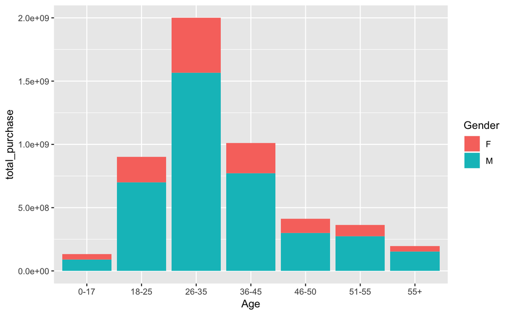

```r
library(ggplot2)
BlackFriday %>%
group_by(Age,Gender) %>%
summarise(total_purchase = sum(Purchase))%>%
  ggplot(aes(x=Age, y = total_purchase)) +
geom_col(aes(fill = Gender))
```

```r
BlackFriday %>%
group_by(User_ID, City_Category) %>%
summarise(total_purchase = sum(Purchase)) %>%
ggplot(aes(x = total_purchase, group = City_Category)) +
geom_histogram(aes(fill=City_Category,binwidth = 300000, center = 150000))
```

[output not shown]

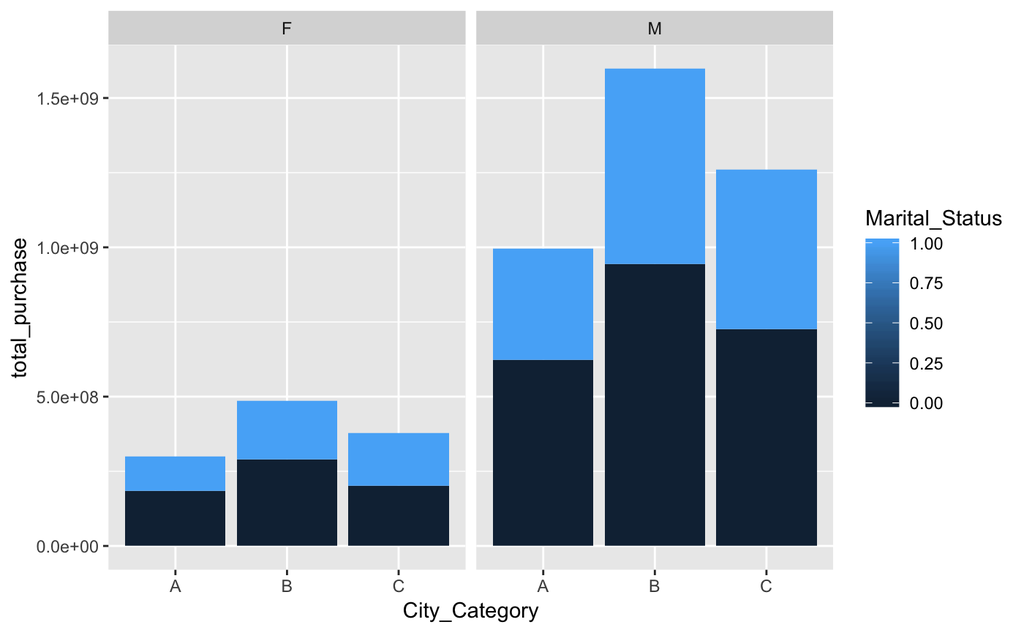

```r
BlackFriday %>%
group_by(City_Category, Marital_Status,Gender) %>%
summarise(total_purchase = sum(Purchase)) %>%
ggplot(aes(x = City_Category, y = total_purchase)) +
 geom_col(aes(fill = Marital_Status))+facet_grid(~ Gender)
```

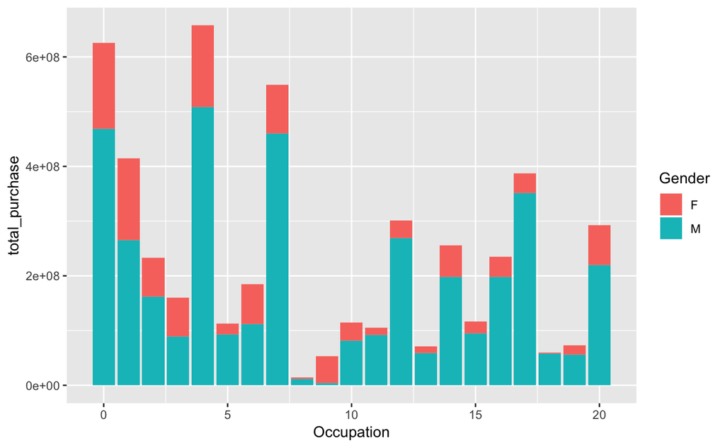

```r
BlackFriday %>%
group_by(Occupation,Gender) %>%
summarise(total_purchase = sum(Purchase))%>%
  ggplot(aes(x=Occupation, y = total_purchase)) +
geom_col(aes(fill = Gender))
```

8.This graph stay in current city years into gender, and then shows the relationship bewteen stay incurrent city years and totap purchase in different gender

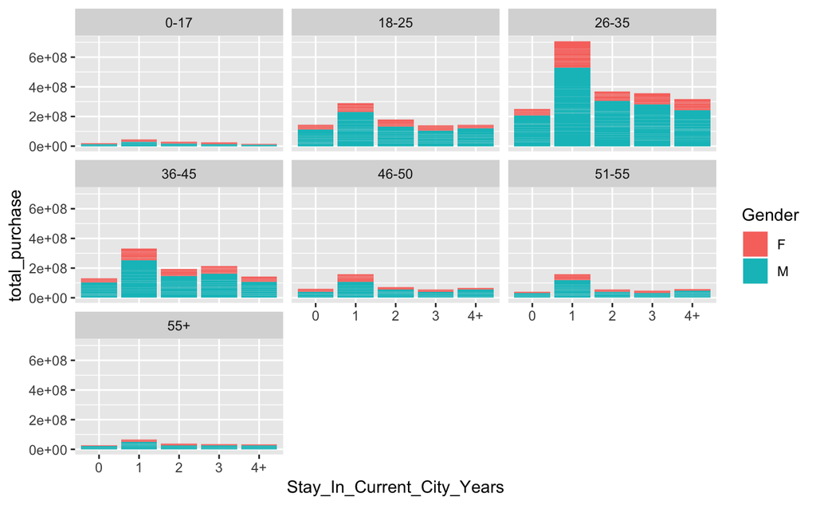

```r
BlackFriday %>%
group_by(Stay_In_Current_City_Years,Gender,Age,Product_Category_2) %>%
summarise(total_purchase = sum(Purchase))%>%
  ggplot(aes(x=Stay_In_Current_City_Years, y = total_purchase)) +
geom_col(aes(fill = Gender))+facet_wrap(Age~.)
```

9. This graph divde product category 1 into age and gender, then shows the relationship between product category 1 and total purchase into different age and gender。This one also proves that there are more male pruchase than female however, I think this because t=some married male paid fro their waives.

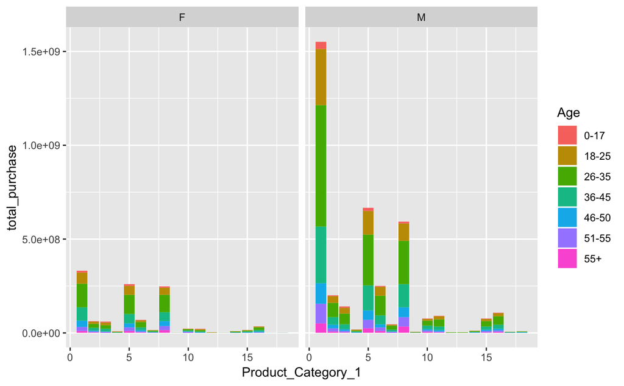

```r
BlackFriday %>%
group_by(Product_Category_1,Age,Gender) %>%
summarise(total_purchase = sum(Purchase))%>%
  ggplot(aes(x=Product_Category_1, y = total_purchase)) +
geom_col(aes(fill = Age))+facet_grid(~Gender)
```